# QMSS GR5015 001 2019 3: Independent Project

Are Trade Deficits Bad?

Andrej Arpáš

12/16/2019

# 1 Introduction

This project aims at applying sound quantitative methods and data analytics in the realm of computational and mathematical statistics to economic output and the trade deficit and the extent to which it can or cannot be said that the latter is “bad” for the former.

Running a trade deficit is what happens when a country imports more than it exports. The converse of that is referred to as a surplus. Both phenomena are forms of a lopsided trade balance, somewhat broader measure of which is the current account. Standard economic theory is unambiguous that the trade deficit is something not to be worried about. This, however, does not appear to be how the trade deficit tends to be perceived by the general public or written about in many a media outlet. The objective of this paper, therefore, is to analyze those metrics that, in one form or another, pertain to the trade deficit, such as I(M)ports, E(X)ports, the Trade Deficit (X-M), GDP data to gauge economic output, and the unemployment rate for the past ten years, from 2008 to 2018. (The data is quarterly and therefore 2019 could not be taken into account seeing that the last quarter has not been reported yet.)

## 1.1 Research Question: “Are Trade Deficits Bad?”

The research question harkens back to the “infamous” econoimc identity Y = G + I + C + NX, where Y denotes output, G government spending, I private investment, C consumer spending, and NX stands for net exports or the difference between exports and imports. It is this last term of the identity that seems to make some believe that since one takes away imports in order to arrive at the Y figure, imports must be bad for the economy. This, however, is merely a book-keeping operation intended to ensure that the final figure not be overestimated. The subtracting is necessary lest imports are double-counted in all the other terms. (Imports are part of certain exports, the consumer spending, investments by companies and domestic manufacturers, and even government procurement allows for foreign-sourced components and so on.) Posing the question in such simplistic terms allows one to arrive at a falsifiable hypothesis and makes modelling more interesting.

## 1.2 Hypothesis & Methods

I shall begin by presuming the trade deficit is indeed bad for the economy. What does “bad” mean in this context? “Bad” will be defined by the data to hold up the following relationship: The greater the trade deficit, the lower the output and vice versa.

(As a corrolary, I will also be tracking unemployment rates over the same time span since unemployment seems to be frequently lumped together with lower economic output, i.e. as yet another victim of the oft-vilified trade deficit. However, since the two are indeed paired up in economic literature, unemployment is largely redundant as a measurement tool in order to study the relationship between the trade deficit and economic output since the output and unemployment could be considered almost complements of sorts in the sense that there might be overlaps in terms of what one may learn about the trade deficit by observing either of the two.)

For the purposes of this paper, output is the dependent variable, and it depends on independent variables in my models, such as the trade deficit, unemployemnt rates and so forth.

The metrics of interest will be estimates of the extent to which GDP/output is predicated on the trade deficit. Statistically significant findings (alpha < 0.05) of a positive association between the trade deficit and the GDP will be taken as indicative of the rejection of the null, and therefore a proof by contradiction that the trade deficit is actually “good” for the economy, i.e. conducive to economic growth.

In the Random Forests (RF) phase of my experiment, the output will be my estimand, estimated by my RF model (the estimator), and the predictions yielded by this model will be my estimates.

# 2 Data Description

The data comes from three primary sources. All data in this project describes the United States economy and comes from U.S. sources only.

## 2.1 GDP

Obtained from the Bureau of Economic Analysis (BEA), the data pertains to the Real Gross Domestic Product, in chained (2012) dollars, seasonally adjusted at annual rates, raw and converted in billions in the RConsole. (2008-2018, quarterly.)

## 2.2 Imports/Exports

Source of this data is the United States International Trade Commission (USITC), Imports for Consumption, i.e. imports physically cleared through Customs (in Customs value), and Domestic Exports (FAS value - i.e. a measure of the total value), i.e. of U.S. or foreign origin if the latter have been significantly enhanced in value in the U.S. so as to be considered “domestic”. The data comes raw, parsed at the 2-digit level (HTS-2) and is downloaded as aggregate and subsequently converted in the RConsole to get billions. The USITC web interface displays the data as monthly and quarterly values are obtained by adding up the months.

## 2.3 Unemployent Rate

This data is reported monthly, in percent terms. Quarterly data is calculated using a mean of the monthly values. It is publicly accessible from the Bureau of Labor Statistics (BLS) website.

# 3 Data Analysis/Modelling

Let’s begin by loading the data…

Cleaning…

```r
rownames(d) <- d$X

#d
d$X <- NULL
#d

e <- as.data.frame(t(d)) # Do a transpose, so that I have orderly columns/vector.
#e
```

Okay, now we’re ready to do some computation. We’re almost done pre-processing. We’ve got columns: GDP ($ Billions), Imports, Exports, Unemployment Rate. All quarterly for ten years from 2008 to 2018.

Now, I may want to do a Boolean on whether there is a trade deficit (1) or not (0). Plus, let’s make another column and call is the TBalance to stand for the Balance-of-Trade, positive would mean Trade Surplus, and negative values would denote the sought after Trade Deficit.

```r
e$TradeDeficit <- ifelse(e$"Exports_Q"-e$"Imports_Q">=0, 0, 1) # For the Boolean Trade Deficit: Y/N?
```

Running this operator and checking the df (data frame), one sees that the U.S. has had a continuous trade deficit for the entire observed period. Having thus confirmed what one might already have suspected, that is, that the U.S. has run a trade deficit the whole time, it makes more sense to create another vector which won’t be the Balance-of-Trade, but instead we shall hone in on the Trade Deficit. Specifically, its quantity/magnitude, i.e. I will be looking at the absolute value of the Trade Deficit. We shall call this column TradeDeficit_Size. (Let’s remind ourselves that the units are what they were for Exports/Imports, i.e. just $US.)

```
## 'data.frame':    44 obs. of  6 variables:
##  $ GDP_Bn            : num  15671 15752 15667 15328 15156 ...
##  $ Imports_Q         : num  4.99e+11 5.47e+11 5.69e+11 4.76e+11 3.53e+11 ...
##  $ Exports_Q         : num  2.86e+11 3.10e+11 3.07e+11 2.67e+11 2.20e+11 ...
##  $ UnemploymentRate_Q: num  5 5.3 6 6.9 8.3 9.3 9.6 9.9 9.8 9.6 ...
##  $ TradeDeficit      : num  1 1 1 1 1 1 1 1 1 1 ...
##  $ TradeDeficit_Size : num  2.13e+11 2.37e+11 2.61e+11 2.09e+11 1.33e+11 ...
```

Okay, we’re ready to do a summary:

```r
summary(e$TradeDeficit_Size)
```

```
##      Min.   1st Qu.    Median      Mean   3rd Qu.      Max.
## 1.330e+11 2.111e+11 2.310e+11 2.259e+11 2.446e+11 3.052e+11
```

```r
summary(e)
```

```
##      GDP_Bn        Imports_Q           Exports_Q
##  Min.   :15134   Min.   :3.527e+11   Min.   :2.197e+11
##  1st Qu.:15741   1st Qu.:5.078e+11   1st Qu.:3.060e+11
##  Median :16467   Median :5.598e+11   Median :3.240e+11
##  Mean   :16700   Mean   :5.415e+11   Mean   :3.156e+11
##  3rd Qu.:17577   3rd Qu.:5.728e+11   3rd Qu.:3.409e+11
##  Max.   :18784   Max.   :6.615e+11   Max.   :3.643e+11
##  UnemploymentRate_Q  TradeDeficit TradeDeficit_Size
##  Min.   :3.800      Min.   :1     Min.   :1.330e+11
##  1st Qu.:4.900      1st Qu.:1     1st Qu.:2.111e+11
##  Median :6.450      Median :1     Median :2.310e+11
##  Mean   :6.686      Mean   :1     Mean   :2.259e+11
##  3rd Qu.:8.375      3rd Qu.:1     3rd Qu.:2.446e+11
##  Max.   :9.900      Max.   :1     Max.   :3.052e+11
```

```r
tibble(e)
```

```
## # A tibble: 44 x 1
##    e$GDP_Bn $Imports_Q $Exports_Q $UnemploymentRa… $TradeDeficit
##       <dbl>      <dbl>      <dbl>            <dbl>         <dbl>
##  1   15671.    4.99e11    2.86e11              5               1
##  2   15752.    5.47e11    3.10e11              5.3             1
##  3   15667     5.69e11    3.07e11              6               1
##  4   15328     4.76e11    2.67e11              6.9             1
##  5   15156.    3.53e11    2.20e11              8.3             1
##  6   15134.    3.60e11    2.23e11              9.3             1
##  7   15189.    4.03e11    2.34e11              9.6             1
##  8   15356.    4.33e11    2.60e11              9.9             1
##  9   15415.    4.23e11    2.62e11              9.8             1
## 10   15557.    4.76e11    2.77e11              9.6             1
## # … with 34 more rows, and 1 more variable: $TradeDeficit_Size <dbl>
```

To just work with USD billions… (Might be easier to work with. It also lines up better with the GDP data, which is in billions.)

```r
e$TradeDeficit_Size_Bn <- as.numeric(as.character(paste(format(round(e$TradeDeficit_Size / 1e9, 1), trim = TRUE))))#, "Bn")
```

Let’s visualize what we’re dealing with:

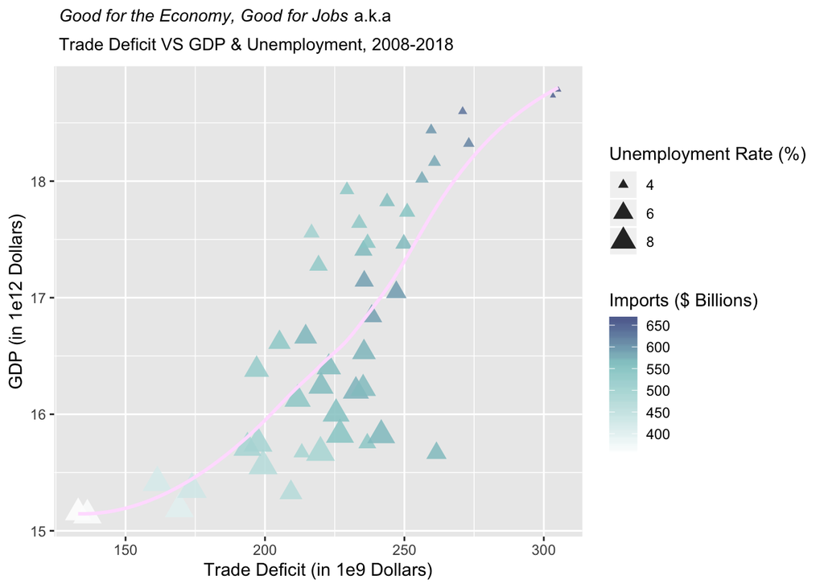

This is informative. We do see, and begin to suspect, that the trade deficit may not be such a bad thing after all. Looking at this chart, I’m expecting those stat. signif. findings to start pouring in. Let’s do a few models. Start with the simplest…

## 3.1 Phase #1: Simple OLS

```r
lm1 <- lm(GDP_Bn ~ TradeDeficit_Size_Bn, data = e)
summary(lm1)
```

```
##
## Call:
## lm(formula = GDP_Bn ~ TradeDeficit_Size_Bn, data = e)
##
## Residuals:
##     Min      1Q  Median      3Q     Max
## -1884.2  -424.6   184.1   526.0  1142.0
##
## Coefficients:
##                       Estimate Std. Error t value Pr(>|t|)
## (Intercept)          11295.136    677.365  16.675  < 2e-16 ***
## TradeDeficit_Size_Bn    23.924      2.962   8.077 4.37e-10 ***
## ---
## Signif. codes:  0 '***' 0.001 '**' 0.01 '*' 0.05 '.' 0.1 ' ' 1
##
## Residual standard error: 699 on 42 degrees of freedom
## Multiple R-squared:  0.6084, Adjusted R-squared:  0.599
## F-statistic: 65.24 on 1 and 42 DF,  p-value: 4.368e-10
```

Now, let’s do something a little more clever…

```r
e$Imports_Bn <- e$Imports_Q / 1e9 # To unify the units.
lm2 <- lm(GDP_Bn ~ (TradeDeficit_Size_Bn + Imports_Bn + UnemploymentRate_Q)^2, data = e)
summary(lm2)
```

```
##
## Call:
## lm(formula = GDP_Bn ~ (TradeDeficit_Size_Bn + Imports_Bn + UnemploymentRate_Q)^2,
##     data = e)
##
## Residuals:
##     Min      1Q  Median      3Q     Max
## -1301.4  -111.2    27.7   216.5   746.1
##
## Coefficients:
##                                           Estimate Std. Error t value
## (Intercept)                             -1.521e+03  6.955e+03  -0.219
## TradeDeficit_Size_Bn                     3.289e+01  3.790e+01   0.868
## Imports_Bn                               3.628e+01  1.726e+01   2.102
## UnemploymentRate_Q                       1.235e+03  4.998e+02   2.470
## TradeDeficit_Size_Bn:Imports_Bn         -5.233e-02  3.571e-02  -1.466
## TradeDeficit_Size_Bn:UnemploymentRate_Q -2.279e+00  4.058e+00  -0.562
## Imports_Bn:UnemploymentRate_Q           -2.057e+00  2.077e+00  -0.991
##                                         Pr(>|t|)
## (Intercept)                               0.8281
## TradeDeficit_Size_Bn                      0.3911
## Imports_Bn                                0.0424 *
## UnemploymentRate_Q                        0.0182 *
## TradeDeficit_Size_Bn:Imports_Bn           0.1512
## TradeDeficit_Size_Bn:UnemploymentRate_Q   0.5778
## Imports_Bn:UnemploymentRate_Q             0.3283
## ---
## Signif. codes:  0 '***' 0.001 '**' 0.01 '*' 0.05 '.' 0.1 ' ' 1
##
## Residual standard error: 425.3 on 37 degrees of freedom
## Multiple R-squared:  0.8723, Adjusted R-squared:  0.8515
## F-statistic:  42.1 on 6 and 37 DF,  p-value: 4.531e-15
```

While this is nice, pair-wise interactions are a good thing just to get the sense of how the data behaves when jostled together, however, doing interactions among everything strains credulity. Try again…

Let’s try an interaction with the unemployment rate, while conditioning the unemployment to hover at about the full-employment level (threshold +-1%), which in the U.S. is generally thought to be 5%…

```r
#class(e$UnemploymentRate_Q)
e$UnemploymentRate_Numeric <- e$UnemploymentRate_Q / 100
lm4 <- lm(GDP_Bn ~ TradeDeficit_Size_Bn:near(UnemploymentRate_Numeric, 0.05, tol = 1e-2), data = e)
summary(lm4)
```

```
##
## Call:
## lm(formula = GDP_Bn ~ TradeDeficit_Size_Bn:near(UnemploymentRate_Numeric,
##     0.05, tol = 0.01), data = e)
##
## Residuals:
##     Min      1Q  Median      3Q     Max
## -2165.7  -209.0   105.6   436.4  1166.5
##
## Coefficients:
##                                                                             Estimate
## (Intercept)                                                                11736.547
## TradeDeficit_Size_Bn:near(UnemploymentRate_Numeric, 0.05, tol = 0.01)FALSE    21.023
## TradeDeficit_Size_Bn:near(UnemploymentRate_Numeric, 0.05, tol = 0.01)TRUE     23.312
##                                                                            Std. Error
## (Intercept)                                                                   661.440
## TradeDeficit_Size_Bn:near(UnemploymentRate_Numeric, 0.05, tol = 0.01)FALSE      3.017
## TradeDeficit_Size_Bn:near(UnemploymentRate_Numeric, 0.05, tol = 0.01)TRUE       2.800
##                                                                            t value
## (Intercept)                                                                 17.744
## TradeDeficit_Size_Bn:near(UnemploymentRate_Numeric, 0.05, tol = 0.01)FALSE   6.968
## TradeDeficit_Size_Bn:near(UnemploymentRate_Numeric, 0.05, tol = 0.01)TRUE    8.327
##                                                                            Pr(>|t|)
## (Intercept)                                                                 < 2e-16
## TradeDeficit_Size_Bn:near(UnemploymentRate_Numeric, 0.05, tol = 0.01)FALSE 1.83e-08
## TradeDeficit_Size_Bn:near(UnemploymentRate_Numeric, 0.05, tol = 0.01)TRUE  2.37e-10
##
## (Intercept)                                                                ***
## TradeDeficit_Size_Bn:near(UnemploymentRate_Numeric, 0.05, tol = 0.01)FALSE ***
## TradeDeficit_Size_Bn:near(UnemploymentRate_Numeric, 0.05, tol = 0.01)TRUE  ***
## ---
## Signif. codes:  0 '***' 0.001 '**' 0.01 '*' 0.05 '.' 0.1 ' ' 1
##
## Residual standard error: 658.3 on 41 degrees of freedom
## Multiple R-squared:  0.661,  Adjusted R-squared:  0.6444
## F-statistic: 39.97 on 2 and 41 DF,  p-value: 2.345e-10
```

When the unemployment rate is within one percent of the full-employment level (i.e. 5%), for each additional billion dollar increase in the trade deficit, the GDP goes up by $23.312bn. (Statistically significant: 2.37e-10 ***.) There does not appear to be much difference within vs. without the bounds, though.

Seems like I’m using up too many degrees of freedom, i.e. the residual error term is iflated by having to estimate too many parameters, thus artificially causing the significance to plummet. (The parameter estimates oughtn’t to change all that much.) Let’s do fewer interactions and only where it makes sense. So, for instance…

```r
lm7 <- lm(GDP_Bn ~ TradeDeficit_Size_Bn + UnemploymentRate_Q, data = e)
summary(lm7)
```

```
##
## Call:
## lm(formula = GDP_Bn ~ TradeDeficit_Size_Bn + UnemploymentRate_Q,
##     data = e)
##
## Residuals:
##      Min       1Q   Median       3Q      Max
## -1607.78   -28.92   132.32   281.80   509.63
##
## Coefficients:
##                       Estimate Std. Error t value Pr(>|t|)
## (Intercept)          16953.103   1042.230  16.266  < 2e-16 ***
## TradeDeficit_Size_Bn     9.341      3.203   2.916  0.00572 **
## UnemploymentRate_Q    -353.492     57.340  -6.165 2.52e-07 ***
## ---
## Signif. codes:  0 '***' 0.001 '**' 0.01 '*' 0.05 '.' 0.1 ' ' 1
##
## Residual standard error: 509.7 on 41 degrees of freedom
## Multiple R-squared:  0.7968, Adjusted R-squared:  0.7868
## F-statistic: 80.36 on 2 and 41 DF,  p-value: 6.524e-15
```

```r
library(stargazer)
stargazer(lm1, lm7, type = "text")
```

```
##
## ==================================================================
##                                   Dependent variable:
##                      ---------------------------------------------
##                                         GDP_Bn
##                               (1)                    (2)
## ------------------------------------------------------------------
## TradeDeficit_Size_Bn       23.924***               9.341***
##                             (2.962)                (3.203)
##
## UnemploymentRate_Q                               -353.492***
##                                                    (57.340)
##
## Constant                 11,295.140***          16,953.100***
##                            (677.365)             (1,042.230)
##
## ------------------------------------------------------------------
## Observations                   44                     44
## R2                           0.608                  0.797
## Adjusted R2                  0.599                  0.787
## Residual Std. Error    699.013 (df = 42)      509.662 (df = 41)
## F Statistic          65.239*** (df = 1; 42) 80.362*** (df = 2; 41)
## ==================================================================
## Note:                                  *p<0.1; **p<0.05; ***p<0.01
```

```r
anova(lm1, lm7)
```

```
## Analysis of Variance Table
##
## Model 1: GDP_Bn ~ TradeDeficit_Size_Bn
## Model 2: GDP_Bn ~ TradeDeficit_Size_Bn + UnemploymentRate_Q
##   Res.Df      RSS Df Sum of Sq      F    Pr(>F)
## 1     42 20521988
## 2     41 10649989  1   9871999 38.005 2.521e-07 ***
## ---
## Signif. codes:  0 '***' 0.001 '**' 0.01 '*' 0.05 '.' 0.1 ' ' 1
```

Although running a partial F-test shows that the new variable improved the model fit, I still think it’s a bad idea to include it.

## 3.2 Phase #2: Ordinal Logit Regression. Try that…

In order to do so, I’ll have to convert the GDP such that y values are 0 <= y <= 1.

```
## Warning in eval(slot(family, "initialize")): response should be ordinal---
## see ordered()
```

```
##
## Call:
## vglm(formula = GDP_ByQuintiles ~ TradeDeficit_Size_Bn, family = propodds,
##     data = g)
##
## Pearson residuals:
##                         Min       1Q  Median       3Q   Max
## logitlink(P[Y>=2]) -13.5972  0.03187  0.1270  0.34114 1.277
## logitlink(P[Y>=3])  -2.7660 -0.34204  0.1016  0.30785 2.721
## logitlink(P[Y>=4])  -1.5271 -0.48488 -0.0552  0.26803 2.102
## logitlink(P[Y>=5])  -0.9875 -0.28621 -0.1209 -0.01817 2.909
##
## Coefficients:
##                       Estimate Std. Error z value Pr(>|z|)
## (Intercept):1        -15.52898    3.64567  -4.260 2.05e-05 ***
## (Intercept):2        -17.30489    3.82081  -4.529 5.92e-06 ***
## (Intercept):3        -18.54772    3.94379  -4.703 2.56e-06 ***
## (Intercept):4        -20.38090    4.13467  -4.929 8.25e-07 ***
## TradeDeficit_Size_Bn   0.07941    0.01696   4.683 2.83e-06 ***
## ---
## Signif. codes:  0 '***' 0.001 '**' 0.01 '*' 0.05 '.' 0.1 ' ' 1
##
## Names of linear predictors: logitlink(P[Y>=2]), logitlink(P[Y>=3]),
## logitlink(P[Y>=4]), logitlink(P[Y>=5])
##
## Residual deviance: 99.7505 on 167 degrees of freedom
##
## Log-likelihood: -49.8752 on 167 degrees of freedom
##
## Number of Fisher scoring iterations: 7
##
## Warning: Hauck-Donner effect detected in the following estimate(s):
## '(Intercept):1'
##
##
## Exponentiated coefficients:
## TradeDeficit_Size_Bn
##             1.082647
```

```r
ordered(g$GDP_ByQuintiles)
```

```
##  [1] Lowest   Low      Lowest   Lowest   Lowest   <NA>     Lowest
##  [8] Lowest   Lowest   Lowest   Low      Low      Low      Low
## [15] Low      Low      Low      Low      Moderate Moderate Moderate
## [22] Moderate Moderate Moderate Moderate Moderate Higher   Higher
## [29] Higher   Higher   Higher   Higher   Higher   Higher   Higher
## [36] High     High     High     High     High     High     High
## [43] High     High
## Levels: Lowest < Low < Moderate < Higher < High
```

This is to check if y is ordered. We get the following output: “Levels: Lowest < Low < Moderate < Higher < High”, which seems pretty ordered to me, so I think we can ignore the Warning message.

Let’s add odd-ratios to the output:

```r
coef.ol1 <- coef(summary(ordinal.logit1))
coef.ol1 <- data.frame(coef.ol1)
coef.ol1[, "Odd Ratio"] <- exp(coef.ol1[, "Estimate"])
class(coef.ol1)
```

```
## [1] "data.frame"
```

```r
colnames(coef.ol1)[colnames(coef.ol1)=="Std..Error"] <- "Std. Error"
colnames(coef.ol1)[colnames(coef.ol1)=="z.value"] <- "z value"
colnames(coef.ol1)[colnames(coef.ol1)=="Pr...z.."] <- "Pr(>|z|)"
coef.ol1
```

```
##                          Estimate Std. Error   z value     Pr(>|z|)
## (Intercept):1        -15.52897953 3.64567324 -4.259564 2.048258e-05
## (Intercept):2        -17.30488502 3.82081463 -4.529109 5.923300e-06
## (Intercept):3        -18.54771890 3.94379171 -4.703017 2.563452e-06
## (Intercept):4        -20.38089995 4.13467149 -4.929267 8.253868e-07
## TradeDeficit_Size_Bn   0.07940868 0.01695638  4.683115 2.825482e-06
##                         Odd Ratio
## (Intercept):1        1.802395e-07
## (Intercept):2        3.051996e-08
## (Intercept):3        8.807001e-09
## (Intercept):4        1.408275e-09
## TradeDeficit_Size_Bn 1.082647e+00
```

For each additional billion dollars in the Trade Deficit, the logit associated with going up one quintile in the GDP increases by ~0.08*** (stat. signif.), as opposed to a lower category, net of other factors. That is, the odds of the GDP going up one quintile, as opposed to a lower quintile, net of all else, inrease some 8.27%***.

Let’s confirm the results running the regular Logit glm and making some adaptations.

5 categories - 1 = 4 equations.

```r
logit.2345_vs_1 <- glm(GDP_Q2thru5 ~ TradeDeficit_Size_Bn, data = g, family = binomial)
logit.345_vs_12 <- glm(GDP_Q3thru5 ~ TradeDeficit_Size_Bn, data = g, family = binomial)
logit.45_vs_123 <- glm(GDP_Q4Q5 ~ TradeDeficit_Size_Bn, data = g, family = binomial)
logit.5_vs_1234 <- glm(GDP_Q5 ~ TradeDeficit_Size_Bn, data = g, family = binomial)
```

Comparing…

```r
coef.table <- cbind("Logit (2,3,4,5 vs. 1)" = coef(logit.2345_vs_1)[-1], # Removes the Intercept.
                    "Logit (3,4,5 vs. 1,2)" = coef(logit.345_vs_12)[-1], # Removes the Intercept.
                    "Logit (4,5 vs. 1,2,3)" = coef(logit.45_vs_123)[-1],
                    "Logit (5 vs. 1,2,3,4)" = coef(logit.5_vs_1234)[-1],
                    "Ordinal Logit" = coef(ordinal.logit1)[-c(1,2,3,4)]) # Removes the four
# Intercepts/cutpoints.

print(coef.table, digits = 3)
```

```
##                      Logit (2,3,4,5 vs. 1) Logit (3,4,5 vs. 1,2)
## TradeDeficit_Size_Bn                0.0603                0.0517
##                      Logit (4,5 vs. 1,2,3) Logit (5 vs. 1,2,3,4)
## TradeDeficit_Size_Bn                0.0836              -3.7e-17
##                      Ordinal Logit
## TradeDeficit_Size_Bn        0.0794
```

## 3.3 Phase #3: Panel Time Series:

```r
#g <- f %>% mutate(GDP_NumQuint = cut(GDP_Bn, breaks = quintiles,
                                     #labels = c("15.1~15.7","15.7~16.2",
                                                #"16.2~17.0","17.0~17.8",
                                                #"17.8~18.8"))) # In $tn.
#g$GDP_NumQuint
```

One thing I haven’t taken into account yet is that I do have panel data, i.e. really a time series. It’s all just GDP, Trade Deficit ect., but different quarters. Let’s input that as a separate column.

Some cleaning…

```r
#library(data.table)
setDT(e, keep.rownames = TRUE)[]
colnames(e)[colnames(e)=="rn"] <- "Quarters"
str(e)
```

```r
e$Quarters <- sub('.', '', e$Quarters)
e$Quarters <- as.factor(e$Quarters)
class(e$Quarters)
```

```
## [1] "factor"
```

```r
print(levels(e$Quarters))
```

```
##  [1] "2008Q1" "2008Q2" "2008Q3" "2008Q4" "2009Q1" "2009Q2" "2009Q3"
##  [8] "2009Q4" "2010Q1" "2010Q2" "2010Q3" "2010Q4" "2011Q1" "2011Q2"
## [15] "2011Q3" "2011Q4" "2012Q1" "2012Q2" "2012Q3" "2012Q4" "2013Q1"
## [22] "2013Q2" "2013Q3" "2013Q4" "2014Q1" "2014Q2" "2014Q3" "2014Q4"
## [29] "2015Q1" "2015Q2" "2015Q3" "2015Q4" "2016Q1" "2016Q2" "2016Q3"
## [36] "2016Q4" "2017Q1" "2017Q2" "2017Q3" "2017Q4" "2018Q1" "2018Q2"
## [43] "2018Q3" "2018Q4"
```

Now, we’re ready!

First, let’s look at what the data looks like in terms of the time factor.

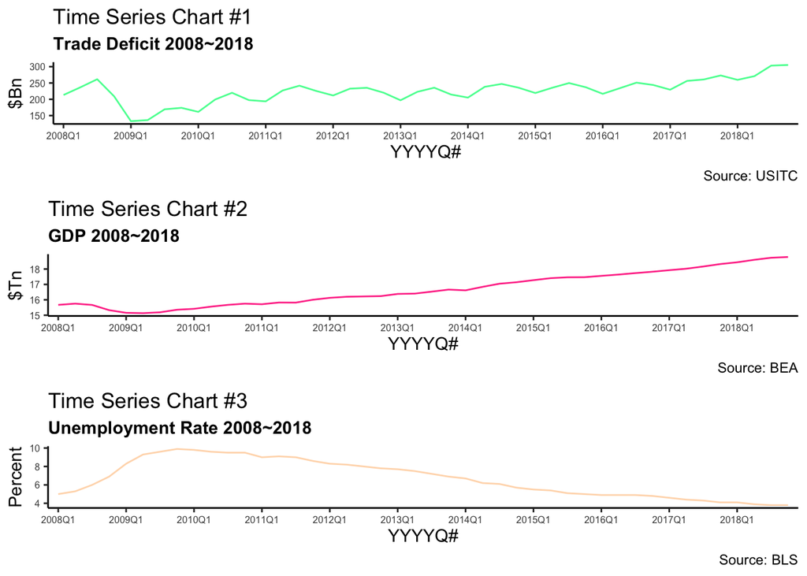

```r
#install.packages("gridExtra")
#library(gridExtra)
grid.arrange(chart1, chart2, chart3)
```

```r
#grid.arrange(chart1, chart2, chart3, nrow = 1) # This is if I wanted it to be 3 charts
# horizontally, one next to the other.
```

Some more time series’ charts might help better understand the data…

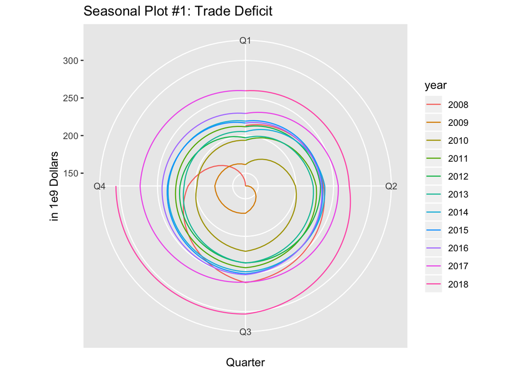

```r
#install.packages("fpp2")
#library(fpp2)
ts_quarters <- ts(as.numeric(e$TradeDeficit_Size_Bn), start = c(2008, 1), end = c(2018, 4),
                  frequency = 4)
ggseasonplot(x = ts_quarters, polar = TRUE) + ylab("in 1e9 Dollars") +
  ggtitle("Seasonal Plot #1: Trade Deficit")
```

Nice, but not all that helpful…

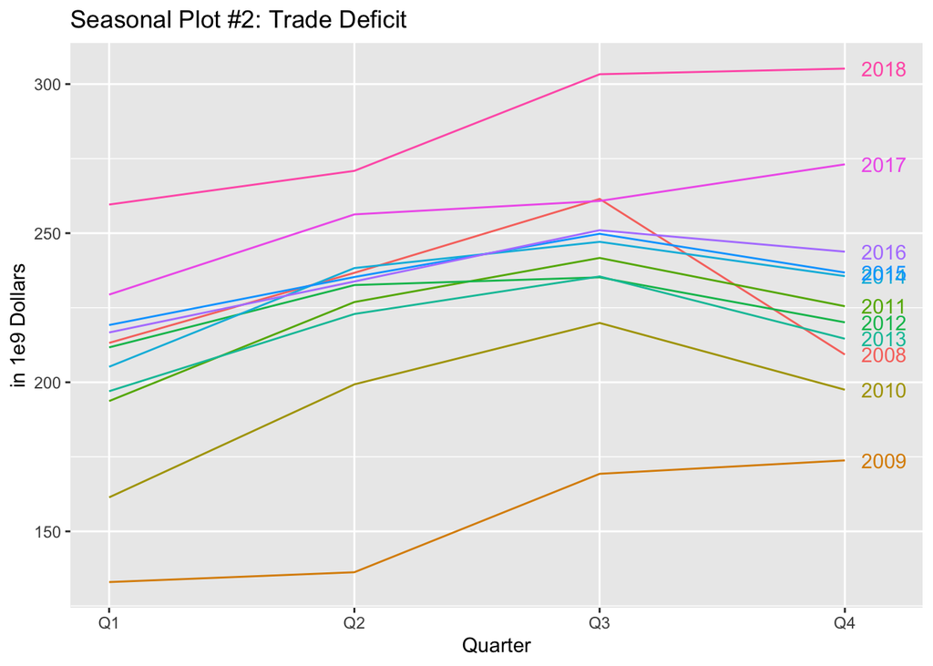

```r
ggseasonplot(x = ts_quarters, year.labels = TRUE, year.labels.left = FALSE) + ylab("in 1e9 Dollars") +
  ggtitle("Seasonal Plot #2: Trade Deficit")
```

That’s better in terms of understanding the seasonality of the trade deficit. So, we see the seasonal/annual patterns. I do however, for the purposes of this project, hone in on just one counrty (the U.S.), which would be my idnum in first differenced regression. It is therefore not necessary to do first differences. Instead of the First Differences then, let’s do something predictive, like Random Forests with time data.

### 3.3.1 Random Forests & Predicting:

Cleaning part… Creating Time Lags 1. So, going one quarter back to predict the current one… Using GDP in Q_(n-1) to predict GDP in Q_n:

```r
e$Step_1 <- sapply(1:nrow(e), function(x) e$GDP_Bn[x+1])
e$Step_2 <- sapply(1:nrow(e), function(x) e$GDP_Bn[x-1])

e$Step_2[!(sapply(e$Step_2, length))] <- NA # Find zero-length values; replace them with NA.
#is.na(e$Step_2[1]) # Checking if this worked. Yes!
e$Step_1 <- NULL # Cleaning.
colnames(e)[colnames(e)=="Step_2"] <- "GDP_Bn_Lag1" # Cleaning Part 2. Now we're done.

# Same for the Trade Deficit and the Unemployment Rate:
e$Step_1 <- sapply(1:nrow(e), function(x) e$TradeDeficit_Size_Bn[x+1])
e$Step_2 <- sapply(1:nrow(e), function(x) e$TradeDeficit_Size_Bn[x-1])

e$Step_2[!(sapply(e$Step_2, length))] <- NA
#is.na(e$Step_2[1])
e$Step_1 <- NULL
colnames(e)[colnames(e)=="Step_2"] <- "TradeDeficit_Size_Bn_Lag1"

e$Step_1 <- sapply(1:nrow(e), function(x) e$UnemploymentRate_Q[x+1])
e$Step_2 <- sapply(1:nrow(e), function(x) e$UnemploymentRate_Q[x-1])

e$Step_2[!(sapply(e$Step_2, length))] <- NA
#is.na(e$Step_2[1])
e$Step_1 <- NULL
colnames(e)[colnames(e)=="Step_2"] <- "UnemploymentRate_Q_Lag1"

#class(e$GDP_Bn) This is numeric.
#class(e$GDP_Bn_Lag1) # These things are all lists. Let's change that to numeric.
e$GDP_Bn_Lag1 <- as.numeric(e$GDP_Bn_Lag1)
e$TradeDeficit_Size_Bn_Lag1 <- as.numeric(e$TradeDeficit_Size_Bn_Lag1)
e$UnemploymentRate_Q_Lag1 <- as.numeric(e$UnemploymentRate_Q_Lag1)
#class(e$GDP_Bn_Lag1) # It worked. Yay!
```

```r
#library(randomForest)
#library(caret)

set.seed(12152019) # Today's date.
e$Quarters_Num <- as.numeric(e$Quarters)
training <- e %>% filter(Quarters_Num<=33) # 44 observations * (7.5/10) = 33 observations
# to be committed to training.
#class(e$Quarters)
testing <- e %>% filter(Quarters_Num>33)
```

```r
#install.packages("brant")
#library(brant)
rf <- randomForest(GDP_Bn ~ GDP_Bn_Lag1 + Quarters_Num + TradeDeficit_Size_Bn_Lag1 +
                     UnemploymentRate_Q_Lag1,
                   data = training, importance = TRUE, ntree = 1000, na.action = na.omit)
```

What’s the most important predictor?

```r
imp <- as.data.frame(sort(importance(rf)[, 1],decreasing = TRUE), optional = TRUE)
names(imp) <- "% Inc. MSE"
imp
```

```
##                           % Inc. MSE
## GDP_Bn_Lag1                 26.77326
## Quarters_Num                26.25556
## UnemploymentRate_Q_Lag1     13.18544
## TradeDeficit_Size_Bn_Lag1   10.48791
```

So, there are two conclusions to make here. One is that indeed, since all the trade deficit, the GDP, and the unemployment rate in some quarter_n are, apparently, to a large extend predicated on what the values for these variables were in quarter_n-1, i.e. the previous one. This is to be expected in a time series for data such as the one I have. The second takeaway is that the Unemployment Rate is again acting up as a reflector of some of the other GDP elements, thus this variable’s predictiveness/importance may easily be overestimated by the model.

```r
which.min(rf$mse) # How many trees would suffice to get the smallest MSE?
```

```
## [1] 58
```

Apparently, 58 trees would be enough.

Predict and evaluate on the testing set:

```r
y_hat <- predict(rf, newdata = testing)
defaultSummary(data.frame(obs = testing$GDP_Bn, pred = y_hat))
```

```
##        RMSE    Rsquared         MAE
## 1053.318136    0.380464  967.367506
```

```r
#RMSE.rf <- sqrt(mean((y_hat-testing$GDP_Bn)^2))
#MAE.rf <- mean(abs(y_hat-testing$GDP_Bn))
```

RMSE USD 1053.318136bn, so ~$1.1tn, which is worrying.

Ideally, we would like a smaller RMSE, but that would necessitate more data from more countries and possibly some more variables to throw in the model and to be able to try new models, maybe first differencing.

```r
#y_hat
h <- as.data.frame(y_hat)
h[, c("GDP_Bn", "Quarters", "Quarters_Num")] <- testing[, c("GDP_Bn", "Quarters", "Quarters_Num")]
colnames(h)[colnames(h)=="y_hat"] <- "GDP_Bn_RF"
h
```

```
##    GDP_Bn_RF  GDP_Bn Quarters Quarters_Num
## 1   17202.15 17639.4   2016Q2           34
## 2   17267.55 17735.1   2016Q3           35
## 3   17318.00 17824.2   2016Q4           36
## 4   17319.37 17925.3   2017Q1           37
## 5   17255.27 18021.0   2017Q2           38
## 6   17196.72 18163.6   2017Q3           39
## 7   17196.72 18322.5   2017Q4           40
## 8   17196.72 18438.3   2018Q1           41
## 9   17196.72 18598.1   2018Q2           42
## 10  17196.72 18732.7   2018Q3           43
## 11  17196.72 18783.5   2018Q4           44
```

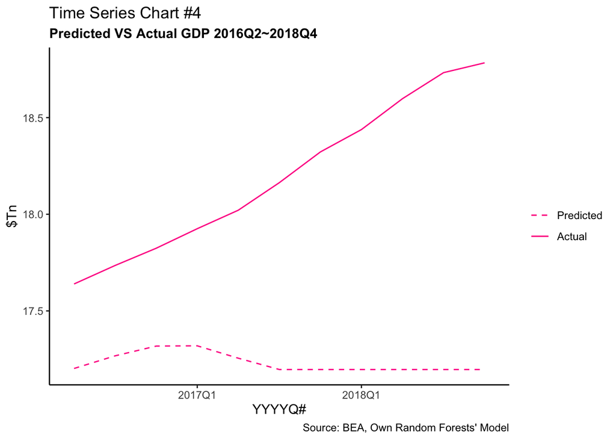

Performs subpar on account of having too few observations (quarterly GDP data). This needs a Bayesian approach to get fixed. That being said, what I find is that my best model so far was the Ordinal Logit.

# 4 Findings/Conclusions

I have found that the most sensible model to use for this analysis was an Ordinal Logit Regression, which delivered statistically significant resutls.

According to this model, for each additional billion dollar increase in the Trade Deficit, the logit associated with going up one quintile in the GDP category increases by ~0.08*** (stat. signif.), as opposed to a lower category, net of other factors. That is, the odds of the GDP going up one quintile, as opposed to a lower quintile, net of all else, inrease some 8.27%*** (statistical significance > 99.9%.). This would indicate a positive relationship between the trade deficit and the output. Further research is necessary to explore some other interactions and to iron out deficiencies in the panel time series predictivity of random forests given the nature of the present data. More countries would also have to be taken into account if generalizations were to be made. This, however, is a promising start.